# 第5回 正則化による多重共線性の問題への対処

## 20回とも選ばれたのは3本

5節 ⑦ ばらつく選択●○○

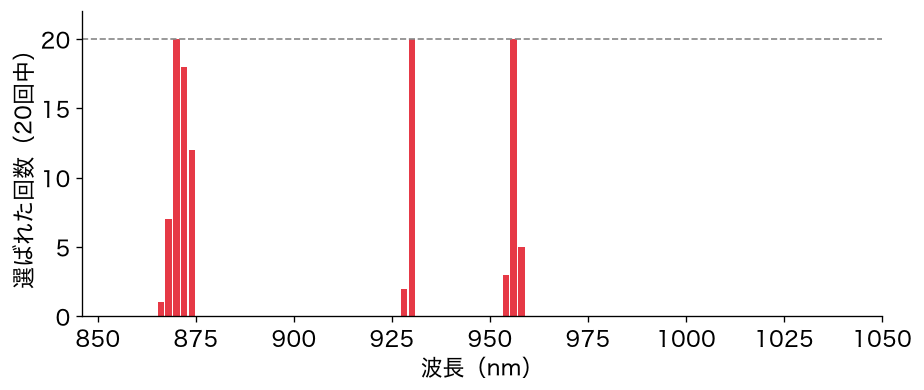

- 20回とも選ばれたのは870・930・956nmだけ
- 872nmは18回、874nmは12回、868nmは7回。隣どうしで入れ替わる

## たまたま1本を選ぶ

5節 ⑦ ばらつく選択●●○

- 870〜874nmは、ほとんど同じことを言う群れ
- ラッソは、群れの中から、たまたま1〜2本を選ぶ
- 選ばれなかった隣の波長も、同じくらい効いているはず

## 重要：ラッソは群れから1本

5節 ⑦ ばらつく選択●●●

ラッソは、似た列の群れから1本をたまたま選ぶ。選ばれなかった列が効かないとは限らない。

## 重要概念：辞書

5節 ⑧ 重要概念●

名札（キー）と中身（値）の組をためる入れ物が辞書。`d[キー] = 値`でしまい、`d[キー]`で名前から引く。

## TODO④：ラッソのαを替える

5節 ⑨ αを替える●

```python
# TODO: 100 を 30 に替えて実行する
counts_x = {}
for w in waves:
    counts_x[w] = 0
for s in range(20):
    for w in picked(Lasso(alpha=100, max_iter=100000), s):
        counts_x[w] = counts_x[w] + 1
plt.bar(nm, list(counts_x.values()), width=1.6)
plt.show()
```

- 予想：ペナルティを弱く（30に）すると、選ばれる波長と、その揺れはどうなる？

## ここまでで分かったこと

5節 10 分かったこと●

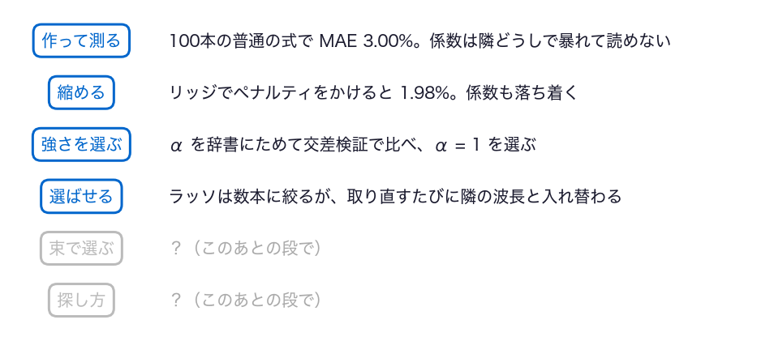

- まだ分からない：揺れずに、効く波長を選べるか

## ノートへ：5節

5節 11 ノートへ●

- 5節のセルを上から実行し、スライドと同じ数が出るか確かめる
- TODO④：予想を書く → `100`を`30`に替えて実行 → 予想と比べる

動画の人は、ここで一時停止。

## 答え合わせ：TODO④

5節 12 答え合わせ●○

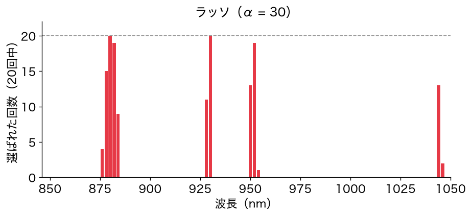

```
20回とも ['880', '930']
878nm 15  882nm 19  950nm 13  952nm 19
```

- ペナルティを弱くすると、選ばれる波長は増える。でも20回ともは2本だけ

## 弱くしても、揺れは消えない

5節 12 答え合わせ●●

- 878と882、950と952のように、やはり隣どうしで入れ替わる
- 揺れは、ペナルティの強さではなく、似た列の群れから生まれている

# 6. 揺れずに選ぶには？

## 段5：束で選ぶ

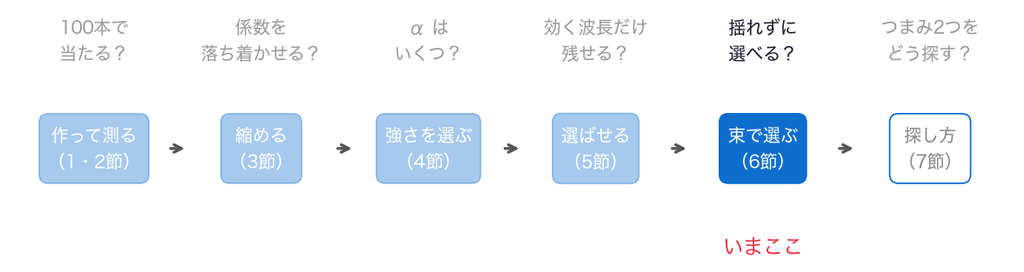

- 問い：似た波長の群れを、揺れずに選べるか
- ラッソは、群れからたまたま1本を選んでいた

## 前の段から

6節 ① 前の段から●

- リッジは、似た列で手柄を分け合った。でも0にはしない
- ラッソは、0にして選んだ。でも群れから1本だけ
- 2つのペナルティを混ぜたら、群れごと選べないか

## 2つのペナルティを混ぜる

6節 ② エラスティックネット●○

$$\alpha \left( r \sum_{j} \lvert b_j \rvert + \frac{1 - r}{2} \sum_{j} b_j^2 \right)$$

- 絶対値のペナルティ（ラッソ）を割合$r$、二乗のペナルティ（リッジ）を残りで混ぜる
- この線形回帰を、エラスティックネット（elastic net）と呼ぶ

## 混ぜる割合r

6節 ② エラスティックネット●●

- $r = 1$ならラッソ、$r$を0に近づけるほどリッジに近い
- 絶対値のペナルティで0にして選び、二乗のペナルティで似た列に手柄を分け合わせる
- scikit-learnでは、$r$を`l1_ratio`と呼ぶ

## お手本：混ぜたペナルティで数える

6節 ③ 帯で残る●○○○○

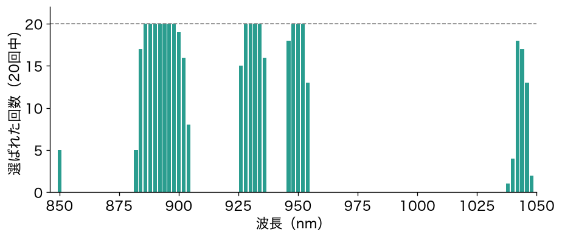

```python
counts_e = {}
for w in waves:
    counts_e[w] = 0
for s in range(20):
    m = ElasticNet(alpha=100, l1_ratio=0.1, max_iter=100000)
    for w in picked(m, s):
        counts_e[w] = counts_e[w] + 1
plt.bar(nm, list(counts_e.values()), width=1.6)
plt.xlabel('波長（nm）')
plt.ylabel('選ばれた回数（20回中）')
plt.show()
```

## お手本：20回とも選ばれた波長

6節 ③ 帯で残る●●○○○

```python
always = []
for w in counts_e:
    if counts_e[w] == 20:
        always.append(w)
print(always)
```

```
['886', '888', '890', '892', '894', '896', '898', '928', '930', '932', '934', '948', '950', '952']
```

- 辞書の名札を1つずつ見て、中身が20の名札だけをリストに集める

## 隣どうしが、まとめて残る

6節 ③ 帯で残る●●●○○

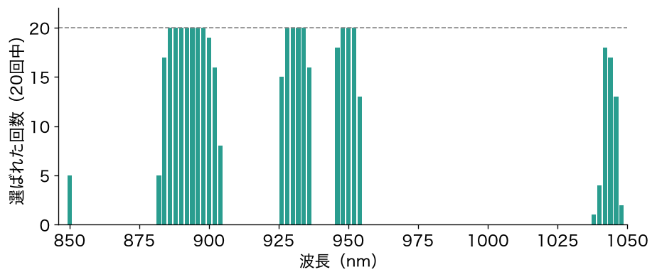

```
20回とも選ばれた帯 886〜898、928〜934、948〜952
```

- 20回とも選ばれた波長が、隣どうしでつながって帯になる

## 群れごと選ぶ

6節 ③ 帯で残る●●●●○

- ラッソでは、群れから1本が入れ替わりで選ばれた
- エラスティックネットは、群れの全員に、手柄を分け合わせる
- 似た列の多いデータでは、選んだ帯が揺れにくい

## 外れは？

6節 ③ 帯で残る●●●●●

```python
m_e = ElasticNet(alpha=100, l1_ratio=0.1, max_iter=100000)
print(round(np.mean(cv_mae(df, waves, m_e)), 2))
```

```
3.11
```

- 3.11%。ラッソ（3.89%）より良く、リッジ（1.98%）よりは悪い

## TODO⑤：混ぜる割合を替える

6節 ④ 混ぜる割合●

```python
# TODO: 0.1 を 0.5 に替えて実行する
r_x = 0.1
counts_x = {}
for w in waves:
    counts_x[w] = 0
for s in range(20):
    m = ElasticNet(alpha=100, l1_ratio=r_x, max_iter=100000)
    for w in picked(m, s):
        counts_x[w] = counts_x[w] + 1
plt.bar(nm, list(counts_x.values()), width=1.6)
plt.show()
```

- 予想：ラッソ寄り（$r = 0.5$）にすると、帯はどうなる？

## ここまでで分かったこと

6節 ⑤ 分かったこと●

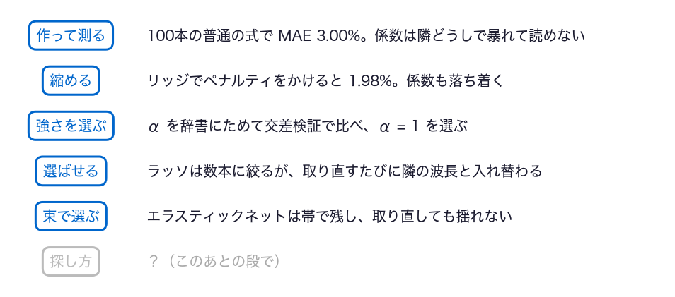

- まだ分からないのは、αとrをどう選ぶか

## ノートへ：6節

6節 ⑥ ノートへ●

- 6節のセルを上から実行し、スライドと同じ数が出るか確かめる
- TODO⑤：予想を書く → `0.1`を`0.5`に替えて実行 → 予想と比べる

動画の人は、ここで一時停止。

## 答え合わせ：TODO⑤

6節 ⑦ 答え合わせ●○

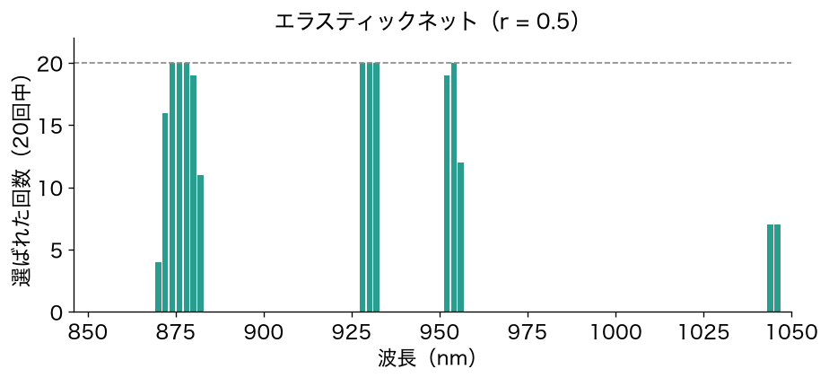

```
20回とも 7 本 ['874', '876', '878', '928', '930', '932', '954']
```

- 20回とも選ばれた波長は7本。r = 0.1の14本から半分に減った

## rを大きくすると、束が細る

6節 ⑦ 答え合わせ●●

- rを1に近づけるほど、ラッソに近づき、群れから少しだけ選ぶ
- rを0に近づけるほど、リッジに近づき、群れごと残す
- αとrの選び方しだいで、選ばれる波長が変わる

# 7. つまみ2つを、どう探す？

## 段6：探し方

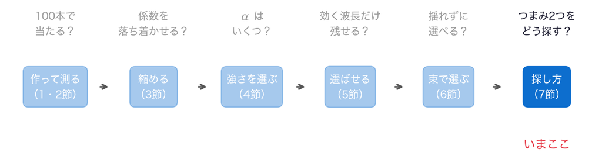

- 問い：αとr、2つのつまみを、どう探すか
- 6節では、α = 100・r = 0.1と決め打ちした

## 前の段から

7節 ① 前の段から●

- 4節では、つまみはαの1つ。候補を辞書にため、交差検証で比べた
- エラスティックネットには、αとrの2つのハイパーパラメータがある
- 探し方は2つ：全部の組を試すか、1つずつ動かすか

## 探し方①：グリッドサーチ

7節 ② グリッドサーチ●○○○○

- αの候補とrの候補を、格子（grid）に並べる
- 格子のすべての組で、交差検証のMAEを測る
- 全部を探すので、グリッドサーチ（grid search）と呼ぶ

## 道具：格子の表を作る

7節 ② グリッドサーチ●●○○○

```python
alphas = [30, 100, 300, 1000]
ratios = [0.2, 0.5, 1.0]
print(grid_mae(alphas, ratios))      # 交差検証のMAE
print(grid_count(alphas, ratios))    # 残る波長の数
```

- `grid_mae`と`grid_count`は、ノートの道具の関数（中身は読み飛ばしてよい）
- 入力は$\alpha$と$r$の候補、出力は行が$r$・列が$\alpha$の表
- αもrも小さい組は、計算が収まりにくく時間がかかるので、候補から外した

## 2つの表を並べる

7節 ② グリッドサーチ●●●○○

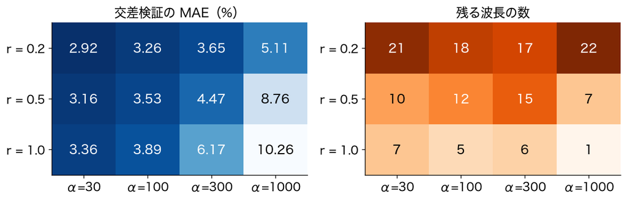

- 左：MAEは、$\alpha$も$r$も小さいほど良い
- 右：残る波長は、$r$が大きいほど少ない

## グリッドサーチの答え

7節 ② グリッドサーチ●●●●○

```python
print(len(alphas) * len(ratios))    # 交差検証をした回数
```

```
12
```

- 12通りでいちばん小さいのは、α = 30・r = 0.2の2.92%。残る波長は21本

## 全部試すと、回数が掛け算で増える

7節 ② グリッドサーチ●●●●●

- 候補が4通りと3通りで、4 × 3 = 12回
- つまみが3つで10通りずつなら、10 × 10 × 10回
- 1回の交差検証で、式を5回作る。時間がかかる

## 探し方②：貪欲法

7節 ③ 貪欲法●○○○○○

- つまみを1つずつ動かす。ほかのつまみは止めておく
- αを止めてrを選び、次にそのrに止めてαを選ぶ
- その場でいちばん良いものを取るので、貪欲法（greedy）と呼ぶ

## お手本：1つずつ動かす関数

7節 ③ 貪欲法●●○○○○

```python
def tune_r(a):
    maes_r = {}
    for r in ratios:
        model = ElasticNet(alpha=a, l1_ratio=r, max_iter=100000)
        maes_r[r] = np.mean(cv_mae(df, waves, model))
    return maes_r


def tune_a(r):
    maes_a = {}
    for a in alphas:
        model = ElasticNet(alpha=a, l1_ratio=r, max_iter=100000)
        maes_a[a] = np.mean(cv_mae(df, waves, model))
    return maes_a
```

- `tune_r`はαを止めて、rの候補ごとのMAEを辞書で返す。`tune_a`はその逆

## お手本：貪欲法で探す

7節 ③ 貪欲法●●●○○○

```python
maes_r = tune_r(100)                   # αを100に止めて、rを動かす
best_r = min(maes_r, key=maes_r.get)
maes_a = tune_a(best_r)                # rを止めて、αを動かす
best_a2 = min(maes_a, key=maes_a.get)
print(best_a2, best_r, round(maes_a[best_a2], 2))
print(len(maes_r) + len(maes_a))       # 交差検証をした回数
```

```
30 0.2 2.92
7
```

- 出発点は、5節のラッソのα = 100

## 貪欲法の通った道

7節 ③ 貪欲法●●●●○○

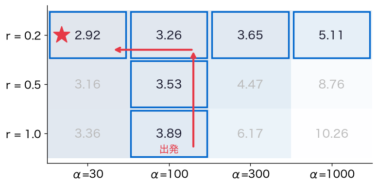

- ①α = 100の列を縦に、②r = 0.2の行を横に。着いたのはα = 30・r = 0.2

## 少ない回数で、同じ組

7節 ③ 貪欲法●●●●●○

- グリッドサーチ：12回で、α = 30・r = 0.2の2.92%
- 貪欲法：7回で、同じα = 30・r = 0.2に着いた
- このデータでは、外れの谷が素直なので、1つずつでも谷底に着く

## 貪欲法が見逃すとき

7節 ③ 貪欲法●●●●●●

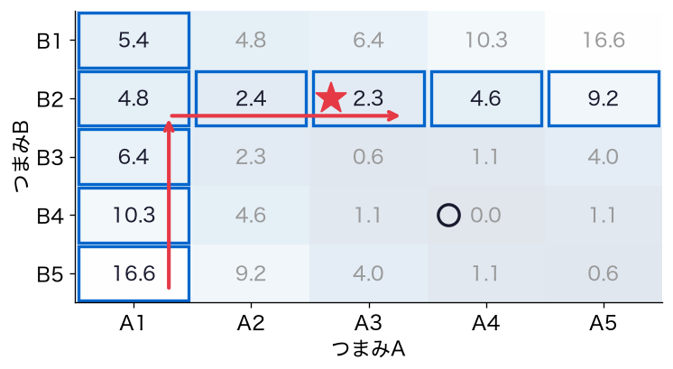

- 作り物の表。2つのつまみが絡み、谷が斜めに走る
- 1つずつ動かすと★で止まる。谷底（○）には届かない

## 重要概念：ハイパーパラメータ

7節 ④ 重要概念●

ハイパーパラメータは、候補を並べ、交差検証で比べて選ぶ（チューニング）。全部の組を試すグリッドサーチは確実だが回数が掛け算で増え、1つずつ動かす貪欲法は速いが、いちばん良い組を見逃すことがある。

## 何のために選ぶか

7節 ⑤ 目的で選ぶ●○

- 当てるだけなら、リッジ（1.98%）がいちばん良い
- 波長を選んで説明したいなら、エラスティックネット
- 選んだ組（α = 30・r = 0.2）は21本で2.92%。6節の組の3.11%より良い

## 重要：目的で選ぶ

7節 ⑤ 目的で選ぶ●●

波長を選ぶと、当たりは少し落ちる。当てるためか、説明するためかで、ペナルティの種類を選ぶ。

## 残った帯は、どこ？

7節 ⑥ えっ●○○

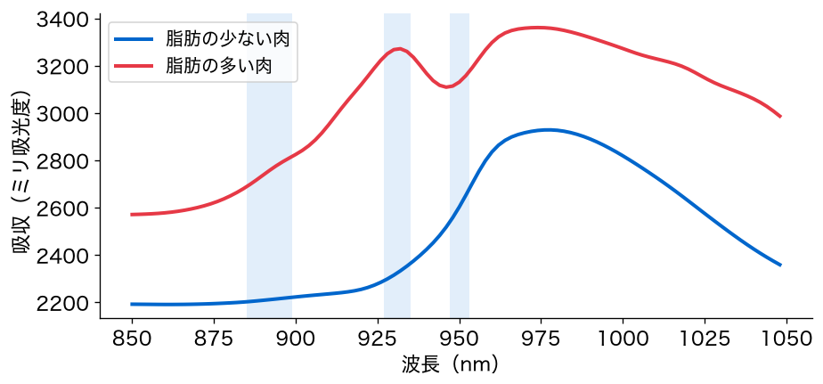

- 青い帯が、エラスティックネットが20回とも残した波長

## 930nmは、脂肪が吸う波長

7節 ⑥ えっ●●○

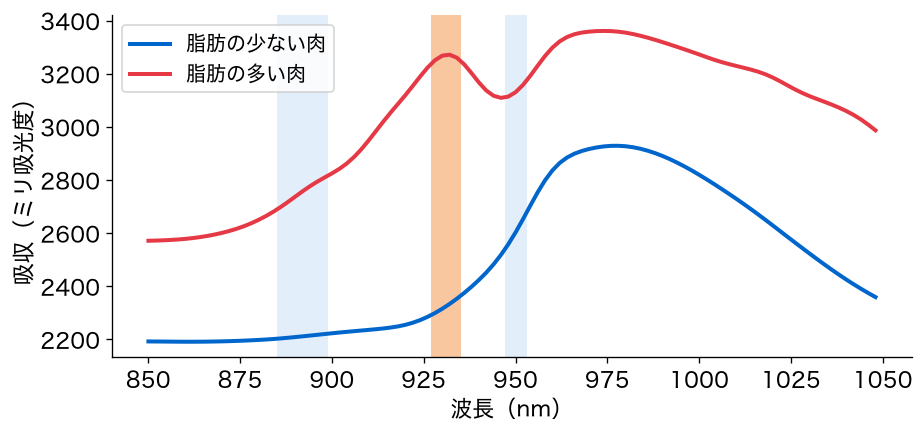

- 930nmのまわりは、脂肪の分子（炭素と水素の結びつき）が光を吸う波長
- 脂肪の多い肉は、930nmのあたりに小さな山がある

## データが、化学を見つけた

7節 ⑥ えっ●●●

- 化学の知識を何も教えていないのに、式は930nmのまわりを選んだ
- 正則化で係数を落ち着かせ、群れごと選んだから、読める形になった
- ほかの帯が何を表すかは、まだ言えない

## TODO⑥：αの候補を1つ足す

7節 ⑦ 候補を足す●

```python
# TODO: alphas の最後に 3000 を足して実行する
alphas = [30, 100, 300, 1000]
print(len(alphas) * len(ratios))       # グリッドサーチの回数
maes_r = tune_r(100)
best_r = min(maes_r, key=maes_r.get)
maes_a = tune_a(best_r)
print(len(maes_r) + len(maes_a))       # 貪欲法の回数
```

- 予想：候補を1つ足すと、それぞれの回数は何回増える？

## ここまでで分かったこと

7節 ⑧ 分かったこと●

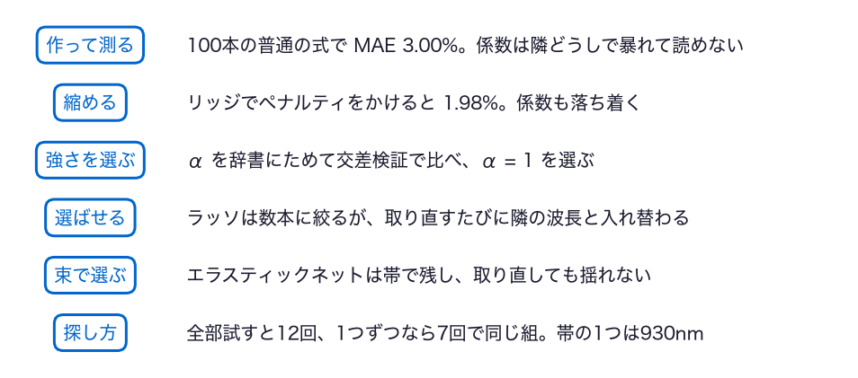

- 6つの段がそろい、今日の問いに答えられる

## ノートへ：7節

7節 ⑨ ノートへ●

- 7節のセルを上から実行し、スライドと同じ数が出るか確かめる
- TODO⑥：予想を書く → `alphas`に`3000`を足して実行 → 予想と比べる

動画の人は、ここで一時停止。

## 答え合わせ：TODO⑥

7節 10 答え合わせ●○

```
15
8
```

- グリッドサーチは12回から15回に、3回増えた（rの候補の数だけ）
- 貪欲法は7回から8回に、1回だけ増えた

## 掛け算と、足し算

7節 10 答え合わせ●●

- グリッドサーチの回数は、候補の数の掛け算。貪欲法は足し算
- つまみや候補が増えるほど、差が開く
- 回数と確かさの折り合いで、探し方を選ぶ

## 答え：外れ2%ほどで分かる

7節 11 答え●

- 光のスペクトルだけで、脂肪の割合は交差検証で平均1.98%の外れ（リッジ）
- 脂肪を教えているのは、930nmのまわりの帯（エラスティックネット）
- 化学分析をしなくても、光で肉の脂肪を見積もれる

## まだ言えないこと

7節 12 まだ言えないこと●

- ほかの帯：890nmや950nmのまわりの帯が、何を表すか
- 水分やたんぱく質：同じ手順で当てられるか、選ぶ波長は同じか
- 肉が違えば：別の工場や別の装置の肉でも、同じ式が使えるか

# まとめ

## 今日の道筋を振り返る

⑨ 振り返る●○○○

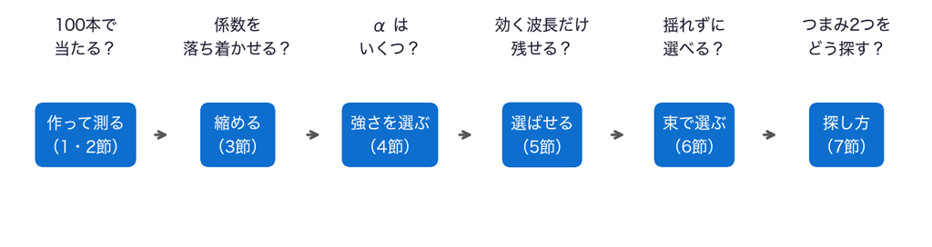

- 6つの段で、100本の係数を落ち着かせ、効く波長を帯で選び、つまみの探し方を比べた

## 今日持ち帰る1文

⑨ 振り返る●●○○

スペクトルのように列が多く、隣どうしが似ていると、普通の式の係数は暴れる。ペナルティをかけて縮める（正則化）と、当たりが良くなり、係数も読める。ラッソは似た列の群れから1本をたまたま選ぶので、群れを束で残すならエラスティックネット。ペナルティの種類と強さは、交差検証で選ぶ。つまみが2つなら、全部の組を試すか、1つずつ動かすか。

## 今日の重要概念

⑨ 振り返る●●●○

統計：ハイパーパラメータは、候補を並べ、交差検証で比べて選ぶ（チューニング）。全部の組を試すグリッドサーチは確実だが回数が掛け算で増え、1つずつ動かす貪欲法は速いが、いちばん良い組を見逃すことがある。

Python：名札（キー）と中身（値）の組をためる入れ物が辞書。`d[キー] = 値`でしまい、`d[キー]`で名前から引く。

## 今日の要点

⑨ 振り返る●●●●

- 似た列がたくさんあると、予測はそこそこでも係数は暴れる（多重共線性）
- リッジは縮める、ラッソは0にして選ぶ、エラスティックネットは束で選ぶ。目的で種類を決める
- ハイパーパラメータは交差検証で選ぶ。全部の組を試すか、1つずつ動かすか

## 列が多いデータは、あちこちにある

10 正則化の広がり●○○

- 遺伝子：1人から2万ほどの遺伝子の量を測れるが、測れる人は数百人
- 画像は1枚に数万の画素、文章は数万の種類の単語
- 試料より列のほうが多いデータは、いまでは珍しくない

## あちこちで働くペナルティ

10 正則化の広がり●●○

- 病気に関わる遺伝子を、数万の中から選ぶ（ラッソ）
- MRIの撮影を短くする技術にも、ラッソと同じ絶対値のペナルティが入っている
- 画像や文章を学ぶAIも、学習のときに係数を縮めるペナルティをかけることが多い

## データが替わっても、同じ形

10 正則化の広がり●●●

- 外れの二乗和にペナルティを足して、いちばん小さくなる係数を探す
- ペナルティの種類は目的で、ペナルティの強さは交差検証で選ぶ
- 肉の脂肪で通した流れは、そのまま別のデータに持っていける

## 課題の出し方

11 このあと●○○

- 今日の重要概念は、統計のハイパーパラメータと、Pythonの辞書
- 2つを1枚ずつ絵にし、2枚をLACSに提出（＝出席。期限なし）
- 手描きの写真でも、描画アプリでもよい。上手でなくてよい

## 次回の問い

11 このあと●●○

- 今日まで、当てたいものは脂肪の割合のような「量」だった
- 当てたいものが「迷惑メッセージか、そうでないか」のような2択だったら？
- 線形回帰の考えで、2択を判定できるか

## このあと：課題へ

11 このあと●●●

- ノートの最後の「課題（提出）」を開く
- 絵を描き終えたら、このあとの「解答」で、絵の例と見比べる

# ここから先は解答

## 課題のあとで見る

- ここから先は、課題の絵を描き終えてから見る
- 絵の例を2つ見せる。上手さではなく、考えが伝わるかを見比べる

## 絵の例：ハイパーパラメータ

- シャワーの、温度と勢いの2つのつまみ（ハイパーパラメータ）
- 全部の組を順に試す（グリッドサーチ）。確実だが、時間がかかる
- 片方ずつ合わせる（貪欲法）。速いが、もっと良い組を見逃すかも

## 絵の例：辞書

- 名札のついた引き出しが並ぶ棚
- 引き出しに中身をしまい、名札を見て、目当ての引き出しを開ける
- リストは番号順の箱。辞書は名札で引く箱

# 発展（任意）

## 隣との差をとる

- TODO①では、隣の3本を組むと、全体の上下が消えて当たった
- それなら、はじめから隣の波長との差を列にしたら？
- スペクトル解析でよく使う前処理（1次微分に近い）

## お手本：差の列を辞書で作る

```python
diffs = {}
for i in range(99):
    diffs[waves[i + 1]] = df[waves[i + 1]] - df[waves[i]]
dd = pd.DataFrame(diffs)
dcols = list(diffs.keys())
dd['脂肪'] = df['脂肪']
dd['組'] = df['組']
```

- `pd.DataFrame(辞書)`：名札を列の名前に、中身を列にした表を作る

## お手本：差の列でラッソ

```python
m_d = Lasso(alpha=10, max_iter=100000)
print(round(np.mean(cv_mae(dd, dcols, m_d)), 2))
m_d.fit(dd[dcols], dd['脂肪'])
coef_d = pd.Series(m_d.coef_, index=dcols)
print(list(coef_d[coef_d != 0].index))
```

```
3.4
['924', '940']
20回とも選ばれた差 ['924', '940']
```

## 山の両側の坂

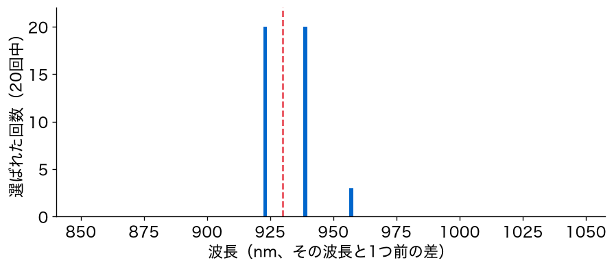

- 差の列なら、ラッソが20回ともほぼ同じ2本を選ぶ
- 930nmの山の、手前の上り坂と、奥の下り坂

## 水分を当てると？

```
水分  平均で当てる 9.33  普通の式 2.24  リッジ 1.65
```

- 答えの列を水分に替えても、リッジが普通の式より当たる
- ノートで、選ばれる波長も確かめてみよう

## おわり

- お疲れさまでした